# Understanding Archetypes of Musical Albums with PCA and K-Means Clustering

Daniel DeFoe

## Intro

Computational grouping through clustering could provide an interesting perspective to us about what music is similar and dissimilar. Human understanding of artistic likeness in music is often confined to labels such as genre, but how do we arrive at genre definition? The landscape of musical art is so vast and constantly evolving that it can be difficult to effectively compare and contrast large groups of content. The makeup of music has so many variables that it would be hard for a human to consider them all effectively and appropriately. Clustering algorithms provide a reduced bias alternative method of grouping content, where the input considerations can be controlled. This is extremely useful because if what is important is considering the comparison of the music itself, then controlling the input to only be the artistic musical elements will limit the algorithm’s view and base its groups only on these artistic elements. The limiting of input will ensure that the algorithm is not affected by the outside influencing factors that humans use as part of their method of grouping content. After groups are created, we can investigate what factors caused them to end up the way they did and we can reconsider the data that we hid from the algorithm before the data was clustered.

This project will carry out clustering of music at the level of albums, with data of individual songs being aggregated by album. After all the aggregation a total of 4,125 albums were considered. More detailed music data would likely produce more sophisticated groupings, but the data used to cluster was Spotify’s API data of songs aggregated to the album level. Principle component analysis will first be carried out to consider combinations of variables that are most useful in separating the data, as this will hopefully reduce the effect of noise in the data. Then the top principle components which together explain the greatest proportion of variance in the data will be clustered using K-means clustering. By clustering the principle components instead of the raw data we hope to have better separated clusters than if we cluster the raw data points, thus better definitions for what these groups mean.

## Data Subset Creations

One dataset is made to include only the average of all the subjective Spotify measures and then another is made to include more expressions(maximums and ranges) of some of these measures.

The genre of the album will be inferred by grabbing the larger, more general common genre names from the list of all the songs genres in the album. First, the top 10 genres from all of the albums will be determined. Ultimately each album will be categorized with these 10 genres when applicable. We will try to establish a primary, secondary, and tertiary genre where applicable.

There is also data for each year on what the estimated three most popular genres of the year were. For each album, it will be determined if the album’s primary genre (Genre1) was one of these three most popular.

Also, because there is data on the release year of the album and the year of the artist’s first album release, it can be worthwhile to consider how long an artist has been active on each current release by calculating the years since the first album.

## Section 1: Principle Component Roadmap

Principle component analysis (PCA) is a form of dimension reduction that takes extracts features from the whole set of input variables to measure how associated each variable is to one another and the relative importance of each of these variables and all of their combinations. The product of PCA is a matrix of loading values for each principle component. All of the principle components together account for 100% of the variance in the data, but the purpose of PCA usually is to take as few principle components as possible to explain the most variance as possible. This means we will ultimately be trying to maximize this trade-off of a number of principle components versus the proportion of the data’s variance explained. The dataset with the complete set of Spotify measures was plugged into PCA and the proportion of the variance captured in each principle component is seen in the barplot.

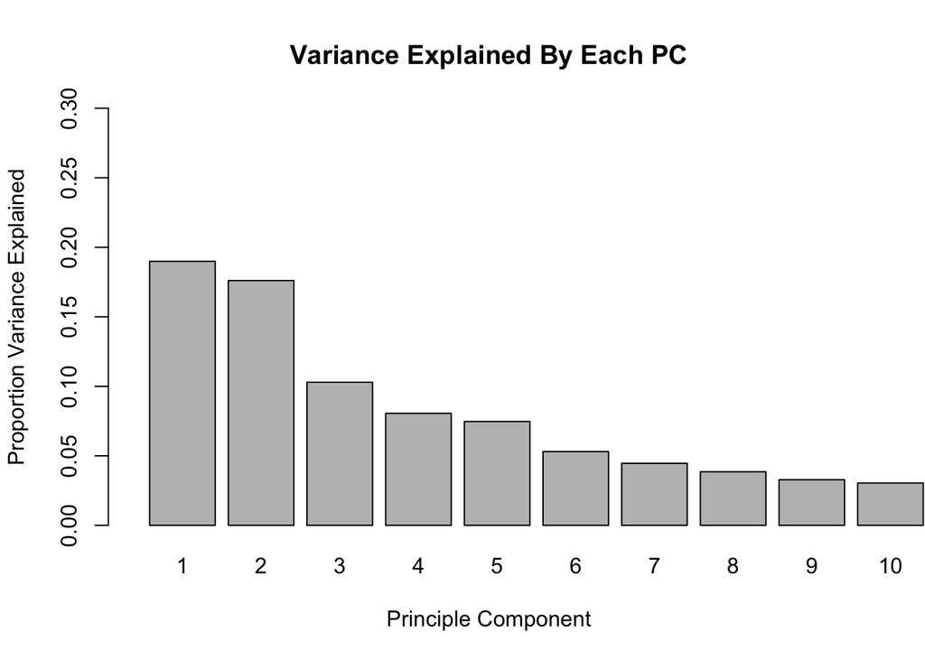

It looks like the first 2 principle components are explaining almost 40% of the variance and then there is a significant decrease in the proportion explained by PC 2 and PC 3 and the next slightly less significant decrease is from PC 5 to PC 6. After the 5th principle component, such little variance is being explained by each following principle component that there would likely be more hindrance than value from them if they were considered in the analysis. For this reason, for the purposes of this investigation, subsets within the first 5 principle components will be considered. The rotation of the principle components shows the vector loadings for the collection of features and a quick analysis of this will be done to attempt to loosely define each of the first 5 principle components.

| VALUE | PC1 | PC2 | PC3 | PC4 | PC5 |
| --- | --- | --- | --- | --- | --- |
| numSongsOnAlb | 0.16914442 | 0.22271157 | -0.262738305 | 0.15654172 | -0.231644809 |
| totalDurationSeconds | 0.07450784 | 0.16658534 | -0.370757647 | 0.23472070 | -0.139906125 |
| avgTempo | -0.123650953 | -0.168012640 | -0.165130913 | 0.01331789 | -0.139250154 |
| rangeTempo | 0.10566258 | 0.19380664 | 0.02353233 | -0.241324395 | -0.259854489 |
| moreCommonMajMin | -0.079460165 | 0.02892098 | 0.01143997 | -0.115467224 | -0.248590294 |
| presenceUncommonTS | -0.047505313 | -0.236775694 | -0.005578516 | 0.18436206 | 0.06483555 |
| totalExplicit | 0.38353906 | 0.01324263 | -0.029081059 | -0.075619480 | 0.16366721 |
| proportionExplicit | 0.37179630 | -0.033292597 | 0.01328602 | -0.099361867 | 0.22690155 |
| avgAcousticness | -0.092169781 | 0.33557397 | 0.26436841 | -0.126219992 | 0.01905263 |
| maxAcousticnessTrack | -0.004183538 | 0.37037854 | 0.14033999 | -0.046596594 | -0.156733900 |
| avgDanceability | 0.28507573 | -0.168619798 | 0.22549601 | 0.32813622 | -0.038647592 |
| maxDanceabilityTrack | 0.32073520 | -0.061647791 | 0.20497368 | 0.33067358 | -0.070715591 |
| rangeEnergy | 0.02378200 | 0.27978979 | -0.067241123 | 0.13806839 | -0.293457182 |
| avgEnergy | 0.06457197 | -0.336501132 | -0.354112691 | -0.007669482 | -0.119731955 |
| maxInstrumentalnessTrack | -0.127382845 | 0.14665945 | -0.254640844 | 0.37506643 | 0.25040019 |
| avgInstrumentalness | -0.140654755 | 0.12339197 | -0.208441096 | 0.38235359 | 0.37276433 |
| avgLiveness | 0.07432435 | 0.07737097 | -0.374833463 | -0.329846710 | 0.05536548 |
| maxLivenessTrack | 0.17401440 | 0.08213442 | -0.396638515 | -0.195896143 | 0.01648279 |
| avgLoudness | 0.03699103 | -0.346353612 | -0.168360402 | -0.051727974 | -0.282059875 |
| rangeLoudness | 0.11389462 | 0.32742330 | -0.035037456 | 0.13657189 | 0.01064065 |
| avgSpeechiness | 0.39201748 | 0.01688582 | 0.01728466 | -0.127042121 | 0.21467813 |
| maxSpeechinessTrack | 0.39075990 | 0.07844367 | -0.021790388 | -0.063297865 | 0.12520563 |
| avgValence | 0.19585704 | -0.182235242 | 0.12439369 | 0.13044559 | -0.253593220 |
| rangeValence | 0.13116985 | 0.09410718 | -0.014256328 | 0.22868495 | -0.391113858 |

Here we will define that the PC’s can generally be considered as follows: - PC1: Measure of how explicit an album is compiled with how danceable and speechy it is. - PC2: Measure of how low energy, low volume, high dynamic, and acoustic an album is. - PC3: How short an album is, and how its very likely not live with also measuring how acoustic, danceable, and low energy it is. - PC4: Measure of how long, instrumental, happy, and danceable an album is that is not live - PC5: Measure of how short, explicit, instrumental, slow, and sad an album is.

## Section 2: Clustering and Observation of Metadata Distributions

Now that the data has gone through PCA and we have chosen the optimal number of potentially useful principle components and given them each loose definitions, now the data will go through unsupervised K-means clustering. As previously stated, we are clustering the principle components to hopefully reduce the effect of noise in the data from grouping the data effectively based on the most distinctive characteristic factors. For each subset of principle components that we plug into K-means, the within group sum of squared error will be calculated and plotted against the number of clusters to see the optimal number of groups for the particular input.

The first 5 principle components will be available to cluster but changing the number of top PC’s we cluster on should hopefully not change the general meaning of the clusters too much. Different combinations of the first N principle components and different values of K will be tested to see what factors are defining the clusters most prominently. The greatest decrease in variance explained by far is after the 2nd principle component, and the next notable decrease is between the 5th and 6th principle. For these reasons, the first 5 principle components could have the potential to be the most useful; therefore, various clustering combinations using the first 5 principle components will be compared. Given a constant number of clusters K, we should expect a reasonably similar pattern in the traits of each cluster still.

First the clustering will be done using only the 1st and 2nd principle components. The curve of the within group sum of square error slightly suggests that the best number of clusters is 4, so that will be used.

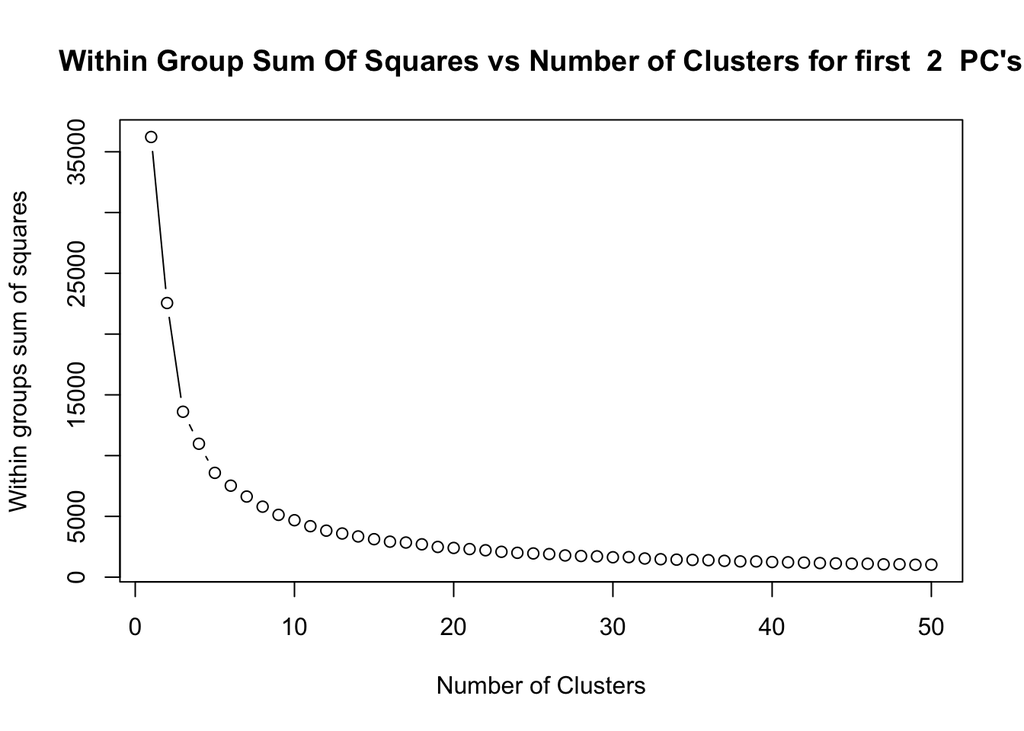

**Average Standardized Album Metric Scores 2 PC’s in 4 Clusters**

| cluster | Danceability | Energy | Acousticness | Speechiness | Instruemntalness | Explicit | Liveness | Valence | Duration | Tempo | MajorMinor | Loudness |
| --- | --- | --- | --- | --- | --- | --- | --- | --- | --- | --- | --- | --- |
| 1 | 0.227 | 0.667 | -0.652 | -0.266 | -0.097 | -0.295 | -0.225 | 0.378 | -0.342 | 0.351 | -0.068 | 0.589 |
| 2 | -0.336 | -0.097 | 0.137 | -0.559 | 0.033 | -0.530 | -0.016 | -0.243 | -0.027 | 0.142 | 0.188 | 0.063 |
| 3 | 0.714 | 0.072 | -0.209 | 1.403 | -0.314 | 1.426 | 0.182 | 0.367 | 0.118 | -0.387 | -0.238 | -0.041 |
| 4 | -0.919 | -1.345 | 1.454 | -0.497 | 0.674 | -0.541 | 0.215 | -0.872 | 0.607 | -0.439 | 0.109 | -1.363 |

This first attempt at clustering seems to form visible groups with some defining characteristics such as one cluster having high acousticness and low energy and danceability and another having high relative speechiness and proportion of explicit songs. The cluster with high speechiness and high proportion of explicit songs was also overwhelmingly represented by albums that had the primary genre of rap. This evidence may suggest that this first model would do a good job at separately grouping rap albums and acoustic albums correctly.

Now the first 3 principle components will be what is clustered on. The within groups sum of squares plot now shows that if may be useful to use 5 clusters. We will try using both 4 and 5 clusters to compare. The first will use 4 clusters.

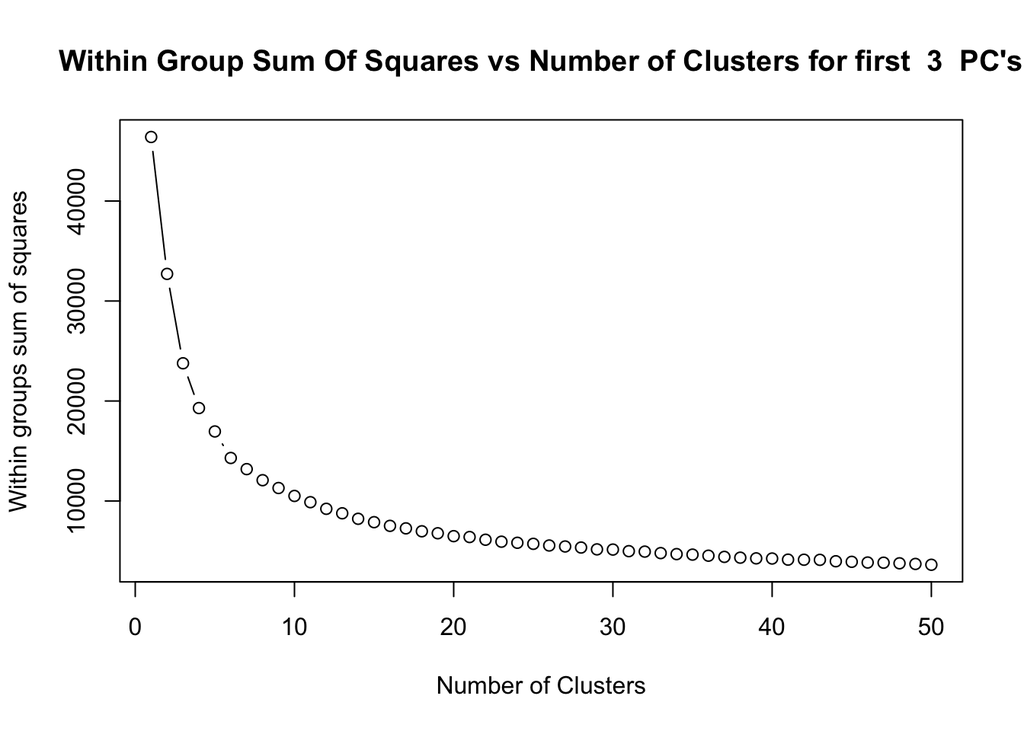

**Average Standardized Album Metric Scores 3 PC’s in 4 Clusters**

| cluster | Danceability | Energy | Acousticness | Speechiness | Instruemntalness | Explicit | Liveness | Valence | Duration | Tempo | MajorMinor | Loudness |
| --- | --- | --- | --- | --- | --- | --- | --- | --- | --- | --- | --- | --- |
| 1 | 0.726 | 0.070 | -0.221 | 1.358 | -0.315 | 1.375 | 0.157 | 0.370 | 0.080 | -0.394 | -0.250 | -0.031 |
| 2 | -0.906 | 0.377 | -0.079 | -0.436 | 0.776 | -0.510 | 1.350 | -0.683 | 1.249 | 0.240 | 0.130 | -0.065 |
| 3 | 0.090 | 0.494 | -0.495 | -0.394 | -0.119 | -0.408 | -0.301 | 0.276 | -0.333 | 0.343 | 0.029 | 0.507 |
| 4 | -0.482 | -1.200 | 1.205 | -0.596 | 0.135 | -0.546 | -0.403 | -0.539 | -0.199 | -0.311 | 0.161 | -0.854 |

It seems that the addition of the third PC helps define another cluster (here cluster 2) as long, instrumental full, live albums. This is a good sign because PC 3 had a significant load for liveness. This is a good addition to the model because we are looking for features of clusters which are different from one another to see separation between them.

Now the same 3 principle components with 5 clusters.

**Average Standardized Album Metric Scores 3 PC’s in 5 Clusters**

| cluster | Danceability | Energy | Acousticness | Speechiness | Instruemntalness | Explicit | Liveness | Valence | Duration | Tempo | MajorMinor | Loudness |
| --- | --- | --- | --- | --- | --- | --- | --- | --- | --- | --- | --- | --- |
| 1 | 0.178 | 0.729 | -0.700 | -0.289 | -0.108 | -0.297 | -0.245 | 0.381 | -0.355 | 0.426 | -0.052 | 0.637 |
| 2 | -0.889 | -1.838 | 1.876 | -0.536 | 0.541 | -0.545 | -0.259 | -0.919 | 0.038 | -0.573 | 0.139 | -1.695 |
| 3 | -0.917 | 0.538 | -0.230 | -0.446 | 0.793 | -0.510 | 1.381 | -0.724 | 1.187 | 0.317 | 0.128 | 0.087 |
| 4 | -0.071 | -0.315 | 0.262 | -0.547 | -0.170 | -0.526 | -0.417 | -0.026 | -0.273 | 0.001 | 0.160 | 0.013 |
| 5 | 0.723 | 0.077 | -0.217 | 1.399 | -0.314 | 1.419 | 0.175 | 0.364 | 0.100 | -0.385 | -0.249 | -0.033 |

Now the first 5 principle components will be clustered on. First only 4 clusters will be used. The number of clusters will be increased until 7 since the within group sum of squares plot seems to decrease steepest until the 7th cluster.

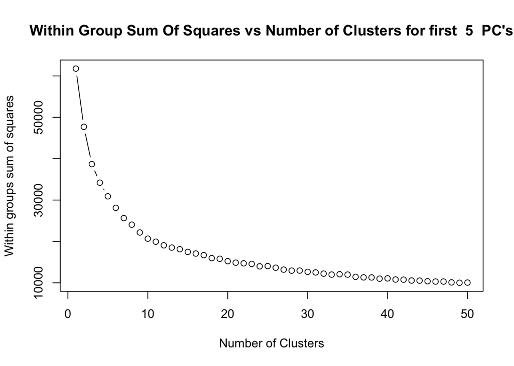

**Average Standardized Album Metric Scores 5 PC’s in 4 Clusters**

| cluster | Danceability | Energy | Acousticness | Speechiness | Instruemntalness | Explicit | Liveness | Valence | Duration | Tempo | MajorMinor | Loudness |
| --- | --- | --- | --- | --- | --- | --- | --- | --- | --- | --- | --- | --- |
| 1 | -0.959 | 0.519 | -0.203 | -0.437 | 0.738 | -0.511 | 1.426 | -0.736 | 1.173 | 0.289 | 0.119 | 0.058 |
| 2 | 0.104 | 0.453 | -0.464 | -0.418 | -0.129 | -0.448 | -0.327 | 0.298 | -0.318 | 0.319 | 0.045 | 0.491 |
| 3 | -0.507 | -1.236 | 1.255 | -0.582 | 0.196 | -0.543 | -0.369 | -0.559 | -0.108 | -0.321 | 0.156 | -0.926 |
| 4 | 0.725 | 0.078 | -0.227 | 1.382 | -0.314 | 1.432 | 0.160 | 0.350 | 0.042 | -0.378 | -0.263 | -0.027 |

Here it seems that the first 5 PC’s give virtually the same results as the first 3. This is a good result for the sake of reliability of 4 clusters doing a good job at separating the data.

Next will be 5 clusters.

**Average Standardized Album Metric Scores 5 PC’s in 5 Clusters**

| cluster | Danceability | Energy | Acousticness | Speechiness | Instruemntalness | Explicit | Liveness | Valence | Duration | Tempo | MajorMinor | Loudness |
| --- | --- | --- | --- | --- | --- | --- | --- | --- | --- | --- | --- | --- |
| 1 | 0.294 | 0.580 | -0.745 | -0.466 | 2.398 | -0.507 | -0.258 | -0.340 | 0.617 | 0.471 | -0.504 | -0.017 |
| 2 | -1.054 | 0.378 | 0.023 | -0.408 | 0.121 | -0.516 | 1.635 | -0.589 | 0.995 | 0.202 | 0.248 | 0.040 |
| 3 | 0.721 | 0.082 | -0.235 | 1.367 | -0.320 | 1.428 | 0.157 | 0.343 | 0.040 | -0.370 | -0.273 | -0.018 |
| 4 | -0.602 | -1.454 | 1.459 | -0.585 | 0.227 | -0.544 | -0.392 | -0.685 | -0.175 | -0.417 | 0.168 | -1.120 |
| 5 | 0.038 | 0.383 | -0.370 | -0.440 | -0.304 | -0.460 | -0.335 | 0.290 | -0.318 | 0.289 | 0.115 | 0.488 |

Now with 6 clusters.

**Average Standardized Album Metric Scores 5 PC’s in 6 Clusters**

| cluster | Danceability | Energy | Acousticness | Speechiness | Instruemntalness | Explicit | Liveness | Valence | Duration | Tempo | MajorMinor | Loudness |
| --- | --- | --- | --- | --- | --- | --- | --- | --- | --- | --- | --- | --- |
| 1 | 0.021 | -0.224 | 0.197 | -0.558 | -0.262 | -0.557 | -0.428 | 0.116 | -0.210 | 0.035 | 0.210 | 0.114 |
| 2 | 0.584 | -0.172 | 0.083 | 1.580 | -0.298 | 1.238 | 0.336 | 0.386 | 0.313 | -0.611 | -0.147 | -0.379 |
| 3 | -1.125 | -1.969 | 2.007 | -0.603 | 0.760 | -0.565 | -0.297 | -1.216 | -0.263 | -0.601 | 0.063 | -1.798 |
| 4 | 0.819 | 0.244 | -0.453 | 1.029 | -0.322 | 1.293 | -0.030 | 0.299 | -0.183 | -0.187 | -0.316 | 0.233 |
| 5 | -0.907 | 0.335 | 0.018 | -0.442 | 0.634 | -0.509 | 1.396 | -0.618 | 1.328 | 0.216 | 0.150 | -0.088 |
| 6 | -0.123 | 0.876 | -0.808 | -0.486 | 0.190 | -0.505 | -0.173 | 0.193 | -0.335 | 0.606 | -0.065 | 0.649 |

It seems that when 6 clusters are initialized that there are 2 clusters with virtually the same characteristics being relatively high in danceability, speechiness, and explicitness. Both clusters were mostly solo male rap albums. This additional cluster does not accomplish much as it seems like it is separating albums which do have similar traits to one another. We cannot see the difference in the data by which this separation is being made, so it does not provide much information.

Finally, with 7 clusters.

**Average Standardized Album Metric Scores 5 PC’s in 7 Clusters**

| cluster | Danceability | Energy | Acousticness | Speechiness | Instruemntalness | Explicit | Liveness | Valence | Duration | Tempo | MajorMinor | Loudness |
| --- | --- | --- | --- | --- | --- | --- | --- | --- | --- | --- | --- | --- |
| 1 | -1.264 | 0.546 | -0.064 | -0.393 | 0.057 | -0.515 | 2.223 | -0.744 | 0.580 | 0.279 | 0.163 | 0.132 |
| 2 | -0.073 | -0.077 | 0.054 | -0.417 | 1.569 | -0.497 | -0.131 | -0.199 | 1.742 | 0.077 | -0.049 | -0.460 |
| 3 | 0.829 | 0.234 | -0.454 | 1.036 | -0.329 | 1.307 | -0.034 | 0.307 | -0.181 | -0.198 | -0.323 | 0.228 |
| 4 | 0.591 | -0.144 | 0.056 | 1.627 | -0.315 | 1.305 | 0.346 | 0.384 | 0.278 | -0.592 | -0.148 | -0.358 |
| 5 | -0.038 | -0.266 | 0.246 | -0.571 | -0.291 | -0.556 | -0.424 | 0.054 | -0.236 | 0.048 | 0.242 | 0.092 |
| 6 | -1.195 | -2.059 | 2.084 | -0.629 | 0.800 | -0.564 | -0.370 | -1.314 | -0.260 | -0.626 | 0.086 | -1.887 |
| 7 | -0.022 | 0.843 | -0.766 | -0.469 | 0.030 | -0.500 | -0.282 | 0.304 | -0.395 | 0.539 | -0.064 | 0.681 |

This appears to give similar results to 6 clusters, where the rap cluster is split without much information as to why and then a new cluster without definitive features is added.

With an extensive search through the different combinations the model which will be chosen to be further observed is the model using the first 5 principle components and 5 clusters.

## Section 3: Specific Questions About Clusters

We have determined the model that used the first 5 PC’s to form 5 clusters was the best, so now we can try to speculate about the groups which were formed. The following visualizations show the properties of albums which make up each cluster.

[output not shown]

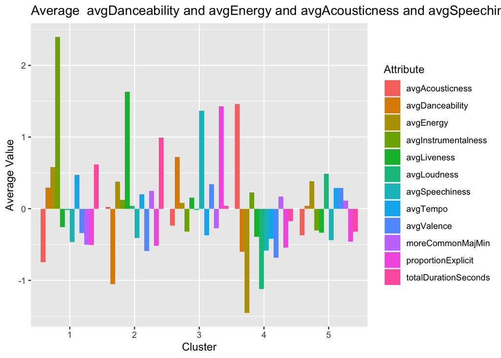

[output not shown]

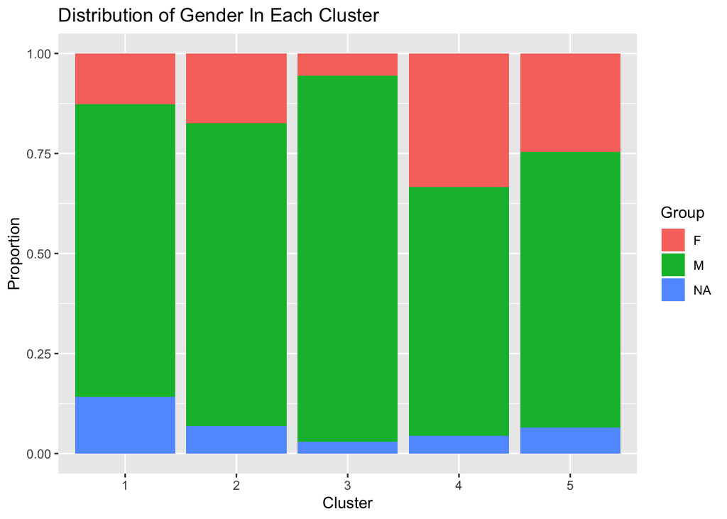

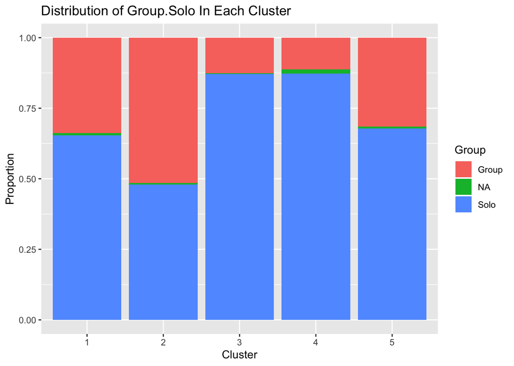

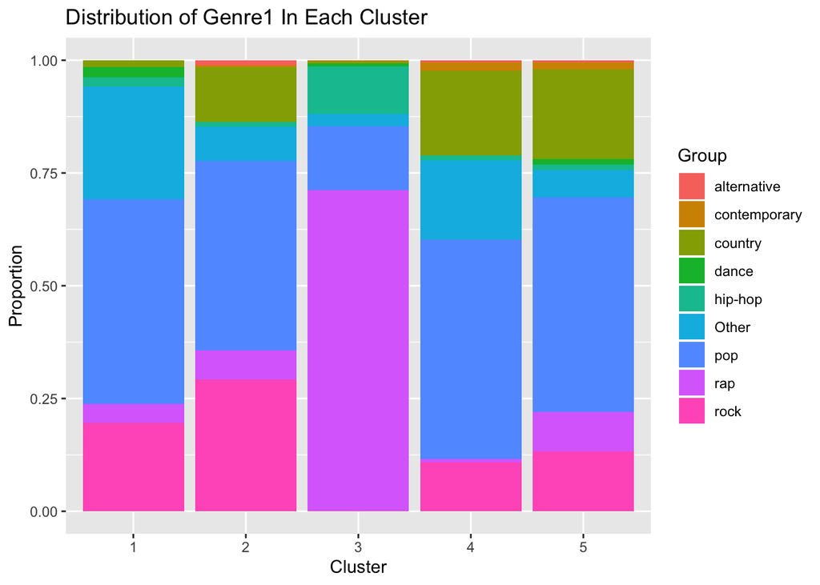

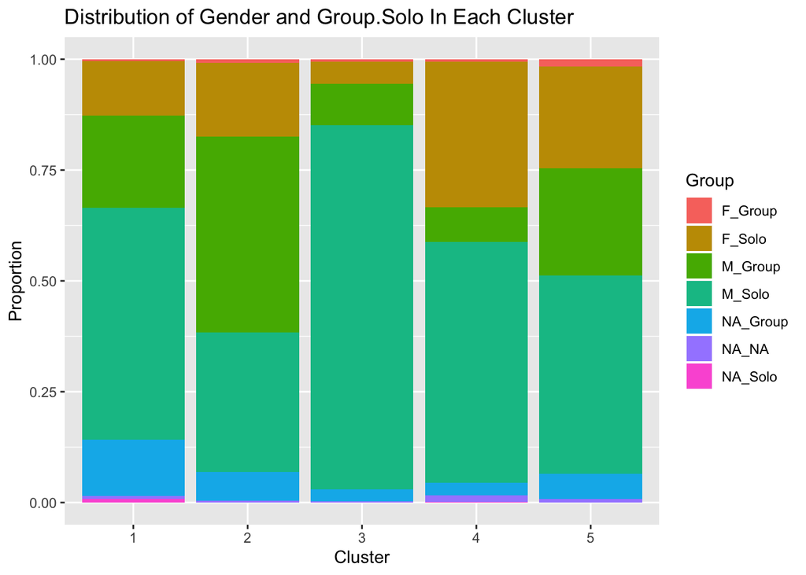

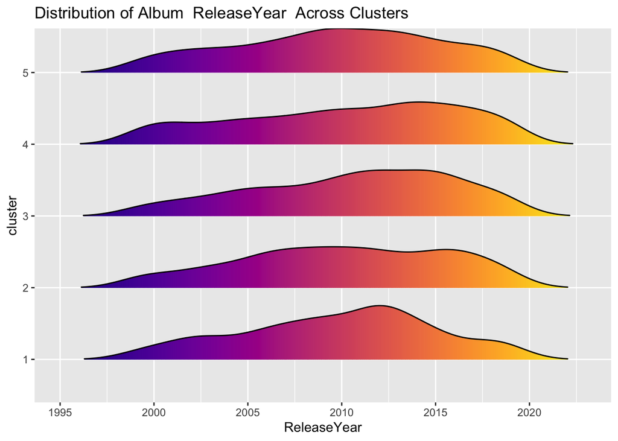

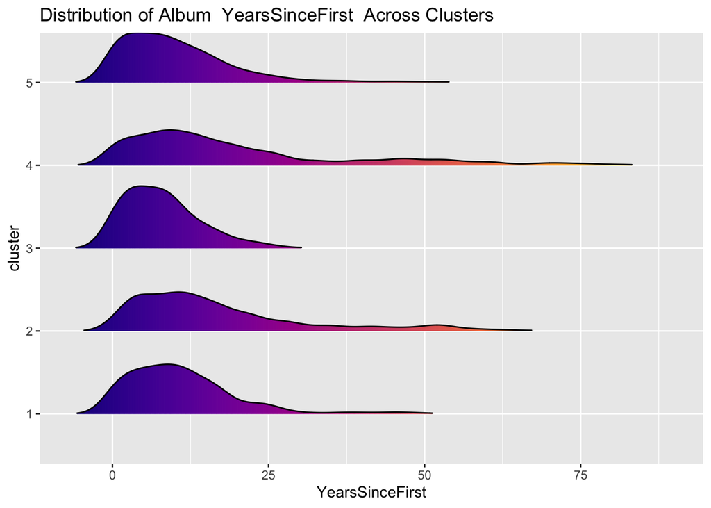

### Question 1: What are the rock albums in the ‘rap cluster’, and why are they there?

With cluster 3 so strongly being represented by primarily rap albums and so lowly being represented by rock albums, it may be worth asking what rock albums are being put into this group if the clustering algorithm seems to be able to separate them so well? What about these rock albums is causing them to be put here?

| id | cluster |
| --- | --- |
| Buried Treasure: Volume 1 (Deluxe Version)—Jimmy Buffett | 3 |
| Tuskegee (Spotify Interview)—Lionel Richie | 3 |

The answer to this is reasonably simple. The rock albums which are being put in cluster 3 are filled with narration tracks. Two rock albums were placed in cluster3 and one was just completely an interview and the other had a discussion track between each song. All this music-less conversation strongly boosts the average speechiness of the album. This high speechiness score is expressed in the combination of PC loadings and ultimately encourages the albums to be clustered with other albums with high amounts of speechiness, and most of these are rap albums.

### Question 2: What is characteristic of the cluster with the highest proportion of female artists? What genres are being covered by these female artists in this cluster high in acousticness?

Males dominated the billboard charts between 1999 and 2019, and each cluster’s proportion of men far outweighed that of women. However, the cluster with the greatest proportion of female representation was cluster 4, which was the group with high acousticness and low energy. These descriptors could apply to various genere labels however, so some further investigation may be done to see which genres that females are playing in this “soft music” cluster. First, a chi-squared test of independence can be done to see if there is a statistically significant difference in the average proportion of each gender’s representation accross the clusters.

```
##
##  Pearson's Chi-squared test
##
## data:  dfReattached$cluster and dfReattached$Gender
## X-squared = 257.29, df = 4, p-value < 2.2e-16
```

| cluster | Gender | n | freq |
| --- | --- | --- | --- |
| 1 | F | 33 | 0.12692308 |
| 1 | M | 190 | 0.73076923 |
| 1 | NA | 37 | 0.14230769 |
| 2 | F | 78 | 0.17410714 |
| 2 | M | 339 | 0.75669643 |
| 2 | NA | 31 | 0.06919643 |
| 3 | F | 59 | 0.05581835 |
| 3 | M | 967 | 0.91485336 |
| 3 | NA | 31 | 0.02932829 |
| 4 | F | 238 | 0.33380084 |
| 4 | M | 443 | 0.62131837 |
| 4 | NA | 32 | 0.04488079 |
| 5 | F | 406 | 0.24650880 |
| 5 | M | 1135 | 0.68913175 |
| 5 | NA | 106 | 0.06435944 |

With a p-value less than 2.2 * e^-16 there is strong evidence to conclude that the average proportions of each gender are not equal in all clusters. This is apparent in the table where we see that albums by females make up 33% of cluster 4 while albums by females only make up 5.6% of cluster 3.

The following graphic shows the distribution of primary genres of albums by female artists across the clusters.

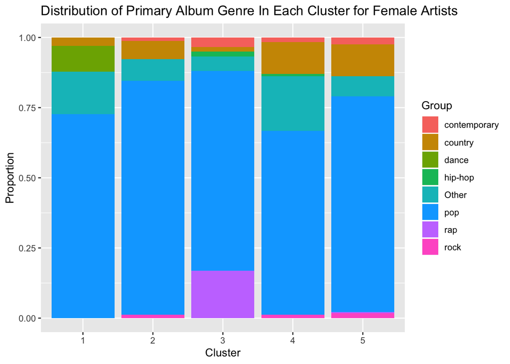

It seems that in the cluster made up of the greatest proportion of female artists (here cluster 4) that pop was the most prevalent genre, but this is true for all the female populations each cluster. Maybe it could help to see the distributions of primary and secondary genre pairings for albums by females in cluster 4.

**Distributions of Primary Genre and Secondary Genre of Albums by Females in Cluster 4**

[interactive chart not shown]

It looks like a good proportion of female pop albums in cluster 4 have a secondary genre of rock or no secondary genre. This cluster’s female albums with a primary genre of country either have a rock or contemporary secondary genre. There is also a notable proportion of female pop albums from cluster 4 with a secondary genre of dance. All of this comes as very interesting considering that cluster 4 could be considered the “acoustic cluster” as it was high in acousticness and low in danceability and energy. Perhaps this means these albums are just representing female releases of the softer sides of each of these genres.

Observing counts of albums of each female artist who was in cluster 4 may help provide some insight as well.

| cluster | Artist | countInClusts |
| --- | --- | --- |
| 4 | Bjork | 13 |
| 4 | Brenda Lee | 11 |
| 4 | Norah Jones | 8 |
| 4 | Lara Fabian | 7 |
| 4 | Sara Bareilles | 6 |
| 4 | Vanessa Carlton | 6 |
| 4 | Amel Larrieux | 4 |
| 4 | Brooke White | 4 |
| 4 | Feist | 4 |
| 4 | Lana Del Rey | 4 |

It seems that the female artists with the most representation in this cluster all play different genres of softer music, and this makes sense because they are in the cluster high in acousticness.

### Question 3: What are the genres being covered by all of these male groups in the cluster with the far greater group density?

Here, cluster 2 will be focused on because it has the greatest proportion of groups, mostly represented by male groups. We already established a significant difference in the proportions of gender in each cluster and we can again use a chi-squared test of independence to test for a difference in the proportion of group and solo artist albums across clusters.

```
##
##  Pearson's Chi-squared test
##
## data:  dfReattached$cluster and dfReattached$Group.Solo
## X-squared = 369.45, df = 4, p-value < 2.2e-16
```

| cluster | Group.Solo | n | freq |
| --- | --- | --- | --- |
| 1 | Group | 88 | 0.338461538 |
| 1 | Solo | 170 | 0.653846154 |
| 1 | NA | 2 | 0.007692308 |
| 2 | Group | 231 | 0.515625000 |
| 2 | Solo | 215 | 0.479910714 |
| 2 | NA | 2 | 0.004464286 |
| 3 | Group | 133 | 0.125827815 |
| 3 | Solo | 921 | 0.871333964 |
| 3 | NA | 3 | 0.002838221 |
| 4 | Group | 80 | 0.112201964 |
| 4 | Solo | 622 | 0.872370266 |
| 4 | NA | 11 | 0.015427770 |
| 5 | Group | 518 | 0.314511233 |
| 5 | Solo | 1117 | 0.678202793 |
| 5 | NA | 12 | 0.007285974 |

Again, with a p-value less than 2.2 * e^-16 there is strong evidence to conclude that the average proportions of group and solo artist albums are not equal in all clusters.

| cluster | Group | countInClusts |
| --- | --- | --- |
| 2 | rock | 100 |
| 2 | pop | 87 |
| 2 | rap | 25 |
| 2 | country | 10 |
| 2 | Other | 5 |
| 2 | alternative | 4 |

The primary genre of albums by groups in this cluster is rock, followed not too far behind by pop. Again, maybe the pairings of primary and secondary genres of the albums could provide better insight.

**Distributions of Primary Genre and Secondary Genre of Albums by Groups in Cluster 2**

[interactive chart not shown]

The rock genre seems to be a part of the tags of many of these group albums in cluster 2, as many of the primary genre pop, rap, and country albums have a secondary genre of rock. Most of the primarily rock albums have a secondary genre of alternative. From the great representation of rock albums in this cluster’s albums released by groups, it could be inferred that the significant representation of group artists in this cluster is due to rock bands of various subgenres.

**Distributions of Primary Genre and Secondary Genre of Albums with Over Average Liveness in Cluster 1**

[interactive chart not shown]

**Distributions of Primary Genre and Secondary Genre of Albums with Over Average Liveness in Cluster 2**

[interactive chart not shown]

```
##
##  Pearson's Chi-squared test
##
## data:  dfReattached1And2$cluster and dfReattached1And2$Genre1
## X-squared = 80.87, df = 8, p-value = 3.267e-14
```

### Question 5: Are there differences the distribution of grammy awards accross clusters?

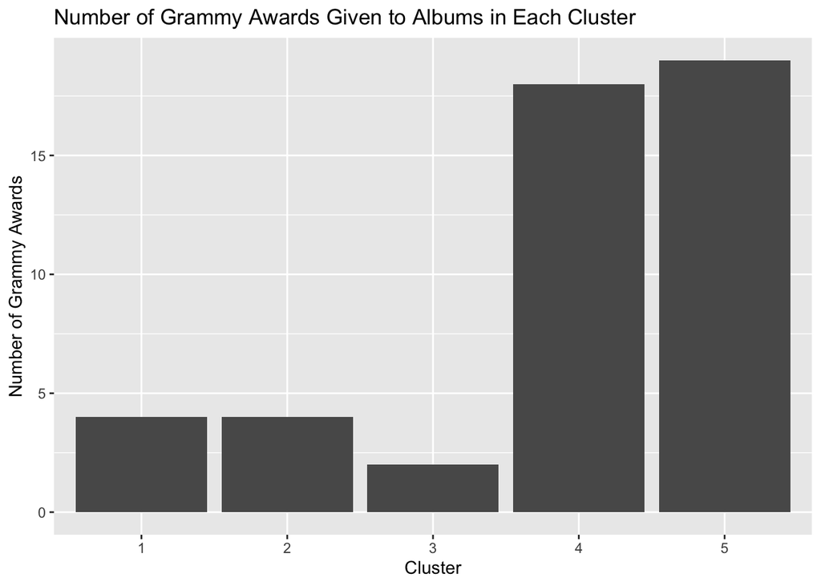

```
##               Df Sum Sq Mean Sq F value  Pr(>F)
## cluster        4   0.24 0.05978   3.958 0.00329 **
## Residuals   4120  62.23 0.01510
## ---
## Signif. codes:  0 '***' 0.001 '**' 0.01 '*' 0.05 '.' 0.1 ' ' 1
```

```
##   Tukey multiple comparisons of means
##     95% family-wise confidence level
##
## Fit: aov(formula = numGrammys ~ cluster, data = dfReattached)
##
## $cluster
##             diff          lwr         upr     p adj
## 2-1 -0.006456044 -0.032603352 0.019691264 0.9620693
## 3-1 -0.013492468 -0.036709396 0.009724461 0.5064975
## 4-1  0.009860826 -0.014436642 0.034158295 0.8026668
## 5-1 -0.003848489 -0.026229408 0.018532430 0.9900748
## 3-2 -0.007036424 -0.025943649 0.011870801 0.8482977
## 4-2  0.016316870 -0.003902535 0.036536276 0.1789610
## 5-2  0.002607555 -0.015263173 0.020478283 0.9947060
## 4-3  0.023353294  0.007100037 0.039606552 0.0008514
## 5-3  0.009643979 -0.003573697 0.022861654 0.2704122
## 5-4 -0.013709316 -0.028744213 0.001325582 0.0934098
```

```
## # A tibble: 5 x 2
##   cluster     val
##   <fct>     <dbl>
## 1 1       0.0154
## 2 2       0.00893
## 3 3       0.00189
## 4 4       0.0252
## 5 5       0.0115
```